# Mixed Effects Models Case Study

```r
suppressPackageStartupMessages(library(tidyverse))
suppressPackageStartupMessages(library(lme4))
suppressPackageStartupMessages(library(knitr))
suppressPackageStartupMessages(library(broom))
suppressPackageStartupMessages(library(Lahman))
```

We will use the Baseball dataset `Teams` available in the `Lahman` package in R, with teams having at least 5 years on record.

```r
dat <- Teams %>%
    count(teamID) %>%
    right_join(Teams, by = "teamID") %>%
    filter(n >= 5) %>%
    select(team = teamID, runs = R, hits = H, walks = BB) %>%
    mutate(hits = scale(hits),
           walks = scale(walks))
head(dat)
```

| team | runs | hits | walks |
| --- | --- | --- | --- |
| BS1 | 401 | -5.627575 | -3.721887 |
| NY2 | 302 | -5.764408 | -3.957769 |
| PH1 | 376 | -5.722763 | -3.844197 |
| BS1 | 521 | -4.134309 | -4.001451 |
| NY2 | 523 | -4.187852 | -3.765569 |
| PH1 | 539 | -4.128359 | -3.643260 |

We will investigate how hits and walks affects total number of runs (data are scaled to improve convergence of model-fitting).

Here is a plot on the effect of walks on runs:

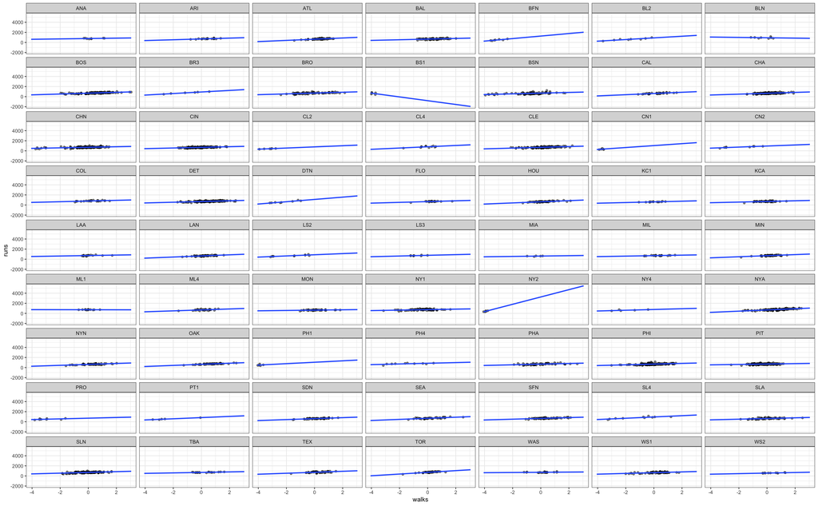

```r
ggplot(dat, aes(walks, runs)) +
    facet_wrap(~team, ncol=7) +
    geom_point(alpha=0.5) +
    geom_smooth(method="lm", se=FALSE,
                fullrange=TRUE, size=1) +
    theme_bw()
```

> How predictors influence each invidual team and how predictors influence the avg team

### Two extremes: pooling and separating

Use a linear model to determine the effect of `hits` and `walks` on `runs`, on an average `team`. Best to allow each team to have its own intercept. Note the standard error on `hits` and `walks`.

```r
lm(runs ~ walks + hits + team, data = dat) %>%
    tidy() %>%
    head()
```

| term | estimate | std.error | statistic | p.value |
| --- | --- | --- | --- | --- |
| (Intercept) | 698.15632 | 22.480744 | 31.055748 | 8.452988e-181 |
| walks | 32.92865 | 1.759448 | 18.715333 | 1.697017e-73 |
| hits | 91.95223 | 1.742049 | 52.783948 | 0.000000e+00 |
| teamARI | -13.13502 | 26.770225 | -0.490658 | 6.237091e-01 |
| teamATL | -30.33275 | 24.177052 | -1.254609 | 2.097315e-01 |
| teamBAL | -25.90344 | 23.873021 | -1.085051 | 2.779980e-01 |

How would you determine the effect of `hits` and `walks` *for each individual team*? Note the standard error on `hits` on a representative team.

```r
lm(runs ~ walks*team + hits*team, data = dat) %>%
    tidy() %>%
    filter(str_detect(term, "hits"))
```

| term | estimate | std.error | statistic | p.value |
| --- | --- | --- | --- | --- |
| hits | 142.670938 | 52.11430 | 2.73765448 | 0.006231380 |
| teamARI:hits | -28.732000 | 64.60788 | -0.44471355 | 0.656564969 |
| teamATL:hits | -48.075311 | 54.28909 | -0.88554282 | 0.375948425 |
| teamBAL:hits | -38.946643 | 53.20177 | -0.73205546 | 0.464202793 |
| teamBFN:hits | -10.351720 | 79.54293 | -0.13014004 | 0.896466018 |
| teamBL2:hits | -32.139835 | 63.66024 | -0.50486511 | 0.613697726 |
| teamBLN:hits | -1.240746 | 61.10944 | -0.02030367 | 0.983802733 |
| teamBOS:hits | -34.416319 | 52.84648 | -0.65125088 | 0.514943931 |
| teamBR3:hits | -110.441018 | 89.63327 | -1.23214307 | 0.218010597 |
| teamBRO:hits | -54.333075 | 53.03376 | -1.02449979 | 0.305697601 |

[output cut: 53 more lines]

Which model yields a smaller SE?

“Pooled” model: artificially small, since data are actually correlated.

“Separate” model: artificially large, since we’re only using data within a particular group.

### An intermediate: mixed effects models

Fit a mixed effects model with random effects on both `hits` and `walks`. Note the SE’s are *in between* the “pooled” and “separate” linear models.

```r
fit_lme <- lmer(runs ~  walks + hits + (walks + hits | team), data = dat)
```

```
Model failed to converge with max|grad| = 0.00600965 (tol = 0.002, component 1)
```

```r
tidy(fit_lme)
```

```
binding factor and character vector, coercing into character vectorbinding character and factor vector, coercing into character vector
```

| term | estimate | std.error | statistic | group |
| --- | --- | --- | --- | --- |
| (Intercept) | 732.63299538 | 12.584167 | 58.218631 | fixed |
| walks | 29.30299693 | 2.995486 | 9.782385 | fixed |
| hits | 97.01335201 | 2.769553 | 35.028522 | fixed |
| sd_(Intercept).team | 96.59677933 | NA | NA | team |
| sd_walks.team | 16.99045251 | NA | NA | team |
| sd_hits.team | 13.95835163 | NA | NA | team |
| cor_(Intercept).walks.team | -0.63391020 | NA | NA | team |
| cor_(Intercept).hits.team | 0.32963901 | NA | NA | team |
| cor_walks.hits.team | -0.04019248 | NA | NA | team |
| sd_Observation.Residual | 60.31575831 | NA | NA | Residual |

Obtain estimates on individual teams:

```r
coef(fit_lme)[[1]]
```

|  | (Intercept) | walks | hits |
| --- | --- | --- | --- |
| ANA | 695.0702 | 34.0940347 | 97.44263 |
| ARI | 679.1122 | 42.4667589 | 98.43117 |
| ATL | 665.0679 | 40.1775114 | 95.96770 |
| BAL | 670.7294 | 35.6378220 | 99.50849 |
| BFN | 831.8831 | 15.1761217 | 101.21392 |
| BL2 | 906.4898 | 15.4242859 | 110.04601 |
| BLN | 851.2463 | 16.2641964 | 109.51643 |
| BOS | 673.3370 | 39.0562376 | 104.07018 |
| BR3 | 927.0623 | 18.3559259 | 111.85415 |
| BRO | 701.2896 | 50.0005976 | 94.23156 |

[output cut: 53 more lines]

Extract the covariance matrix of the fixed effects:

```r
vcov(fit_lme)
```

```
3 x 3 Matrix of class "dpoMatrix"
            (Intercept)      walks      hits
(Intercept)  158.361269 -15.460946  9.135475
walks        -15.460946   8.972935 -1.911420
hits           9.135475  -1.911420  7.670424
```

Extract the covariance matrix of the random effects:

```r
summary(fit_lme)$varcor[[1]]
```

```
            (Intercept)        walks       hits
(Intercept)   9330.9378 -1040.387987 444.462769
walks        -1040.3880   288.675477  -9.531997
hits           444.4628    -9.531997 194.835580
attr(,"stddev")
(Intercept)       walks        hits
   96.59678    16.99045    13.95835
attr(,"correlation")
            (Intercept)       walks        hits
(Intercept)   1.0000000 -0.63391020  0.32963901
walks        -0.6339102  1.00000000 -0.04019248
hits          0.3296390 -0.04019248  1.00000000
```

### Questions

1. Order the models in terms of increasing bias (of regression coefficients)
2. Order the models in terms of increasing variance (of regression coefficients).
3. What is the effect of `hits` on `runs` for team ARI, using the LME?
4. What is the exact distribution of effects (slopes) of `hits` on `runs`?
5. What is the SE of the fixed effect of `hits`?
6. A new team has an average number of hits and walks. Their expected number of runs has what exact distribution?